# Gráfico de control

El gráfico de control es una herramienta útil para determinar si un proceso se encuentra en estado de control, y se utiliza ampliamente como método de análisis y gestión de procesos.

- Explicación del propósito y el principio de uso de los gráficos de control.
- Selección del gráfico de control adecuado según el propósito.
- Cálculo y trazado de las líneas de control para los gráficos de control $ \bar{X} - R $, $ \bar{X}-s $, $ X - Rm $, $ p $, $ np $, $ u $, $ c $.
- Interpretación de los gráficos de control y método para determinar el estado de control estadístico.

[Audio_1](https://drive.google.com/file/d/1mVqlZqtizFIFss-O9j65yVJq7klzJ-hN/view?usp=drive_link)

```python
import os

try:
  os.chdir('../Python/QCKentei2')
except:
  pass

path = os.getcwd()
```

```python
import numpy as np
import matplotlib.pyplot as plt
import pandas as pd

import gspread
from google.oauth2.service_account import Credentials
```

## 05-01 Tipos de gráficos de control

管理図の種類

### 1. ¿Qué es un gráficos de control

管理図とは

El **gráfico de control** es una herramienta que utiliza en el eje vertical los valores de las características, y en el eje horizontal las observaciones consecutivas, que generalmente corresponden al tiempo o al número de muestra. Se emplea para analizar（工程解析） si un proceso está en un estado controlado (estado de control estadístico)（統計的管理状態）, o bien para mantener el proceso en dicho estado (gestión del proceso：工程管理).

- W. A. Shewhart
  - El gráfico de Control, por **W.A. Shewhart**, tiene como objetivo detectar anomalías en un proceso.
- Cuando un proceso varía únicamente debido a **causas aleatorias** (o causas comunes)偶然原因, se dice que está en **estado de control estadístico** (o que el proceso está estadísticamente controlado)異常原因.
- Causa común / Causa aleatoria
  - Variación inevitable que surge incluso al realizar el trabajo de la misma manera de siempre.（避けることが出来ない）
- Causa especial / Causa asignable
  - Variación inconfundible que surge cuando ocurre alguna anomalía en el proceso.（見逃すことのできない）

En un gráfico de control, se establecen los límites de control como criterio para determinar si el proceso está en **estado de control**（管理状態）. Los límites de control se calculan como el valor $ (medio) \pm 3 \times (desviación \_estándar) $. Este tipo de gráfico de control se conoce como gráfico de **control por medio de tres sigmas**( 3σ法）. Si todos los puntos están **dentro de los límites de control**（管理限界内） y **no hay patrones anómalos**（癖のない） en la secuencia de los puntos, se considera que el proceso está en **estado de contro**（管理状態）.

### 2. Tipos de gráficos de control

管理図の種類

Gráfico de control por variables - Característica de calidad medible

- Gráfico de control $ \bar{X} - R $ 平均値と範囲の管理図
  - Tamaño del subgrupo
    - $ n \leq 9 $
- Gráfico de control $ \bar{X} - s $ 平均と標準偏差の管理図
  - Tamaño del subgrupo
    - $ n \geq 10 $
- Gráfico de control $ X $ 個々のデータの管理図
  - Tamaño del subgrupo
    - $ n = 1 $

Gráfico de control por atributos - Número de unidades no conformes

Gráfico de control por atributos - Número de no conformidades

#### 1) Gráfico de control para **análisis**

解析用管理図

El análisis de procesos se refiere a la comprensión cuantitativa de las características de calidad y de los diversos factores del proceso que influyen en ellas.

Los gráficos de control para análisis se utilizan para el análisis de procesos. Su propósito es determinar si un proceso actual está en estado de control estadístico, así como para investigar diferencias entre estratos, basándose en datos clasificados por, por ejemplo, tipo de materia prima, método de fabricación o equipo.

#### 2) Gráfico de control para **gestión**

管理用管理図

Se refiere a los gráficos de control utilizados para mantener este buen estado una vez que el análisis del proceso ha avanzado hasta cierto punto, se han tomado las medidas necesarias y el proceso se encuentra en estado de control estadístico.

[Audio_2](https://drive.google.com/file/d/1NwOGU4B-mLSQgsoI1hWCx2dPXDDIRDhz/view?usp=drive_link)

## 05-02 Cómo elaborar un gráfico de control para análisis

解析用管理図のつくり方

### 1. Cómo elaborar un gráfico de control para datos cuantitativos

計量値の管理図のつくり方

#### (1) Gráfico de control $ \bar{X} - R $

Paso 1: Recolectar los datos y agruparlos データを収集し、群分けする

Paso 2: Calcular la media y el rango de cada grupo 群ごとの平均値と範囲を計算する

Paso 3: Calcular la media general de todas las medias y la media de los rangos 全てのデータの総平均値と範囲の平均値を計算する

Paso 4: Calcular las líneas de control 管理線を計算する

- Línea de control del gráfico $ \bar{X} $
  - Linea central: $ CL = \bar{X}$
  - Límite superior: $ UCL = \bar{X} + A_2 \bar{R} $
  - Límite inferior: $ LCL = \bar{X} - A_2 \bar{R} $
- Línea de control del gráfico $ R $
  - Linea central: $ CL = \bar{R}$
  - Límite superior: $ UCL = D_4 \bar{R} $
  - Límite inferior: $ LCL = D_3 \bar{R} $

[Audio_3](https://drive.google.com/file/d/10rQH7Q0BneCj6oKvmSzd1qr-Ynp--eYA/view?usp=drive_link)

```python
SERVICE_ACCOUNT_FILE = "my-project-vscode-452201-249bdb033f8c.json"  # JSONファイルのパス
SCOPES = ["https://www.googleapis.com/auth/spreadsheets"]

credentials = Credentials.from_service_account_file(SERVICE_ACCOUNT_FILE, scopes=SCOPES)
client = gspread.authorize(credentials)

# スプレッドシートを開く（URLまたはスプレッドシートIDを使用）
SPREADSHEET_ID = "1W4H3VxXJwpKGMu0rE9ocz6yA6J0boG9vGzktgsro1es"
sheet = client.open_by_key(SPREADSHEET_ID).worksheet("Sheet11") # 最初のシートを取得

# データを取得
list_of_lists = sheet.get_all_records()
df = pd.DataFrame(list_of_lists)

df = df.set_index("n")
df = df.apply(pd.to_numeric, errors='coerce')

print("Tabla 5.2")

print(df)
```

```
Tabla 5.2
        A     A2     A3    A4     D1     D2     D3     D4     d2     d3     E2
n
2   2.121  1.880  2.659  1.88    NaN  3.686    NaN  3.267  1.128  0.853  2.659
3   1.732  1.023  1.954  1.19    NaN  4.358    NaN  2.575  1.693  0.888  1.772
4   1.500  0.729  1.628  0.80    NaN  4.698    NaN  2.282  2.059  0.880  1.457
5   1.342  0.577  1.427  0.69    NaN  4.918    NaN  2.114  2.326  0.864  1.290
6   1.225  0.483  1.287  0.55    NaN  5.078    NaN  2.004  2.534  0.848  1.184
7   1.134  0.419  1.182  0.51  0.205  5.469  0.076  1.924  2.704  0.833  1.109
8   1.061  0.373  1.099  0.43  0.387  5.394  0.136  1.864  2.847  0.820  1.054
9   1.000  0.337  1.032  0.41  0.546  5.307  0.184  1.816  2.970  0.808  1.010
10  0.949  0.308  0.975  0.36  0.687  5.203  0.223  1.777  3.078  0.797  0.975
```

Paso 5: Elaborar el gráfico de control.

Paso 6: Graficar los valores de la media y el rango de cada grupo en orden numérico de los grupos.

[Audio_4](https://drive.google.com/file/d/1xPtkF4Spela8pfckm84DB4Lh_AhKHwE5/view?usp=drive_link)

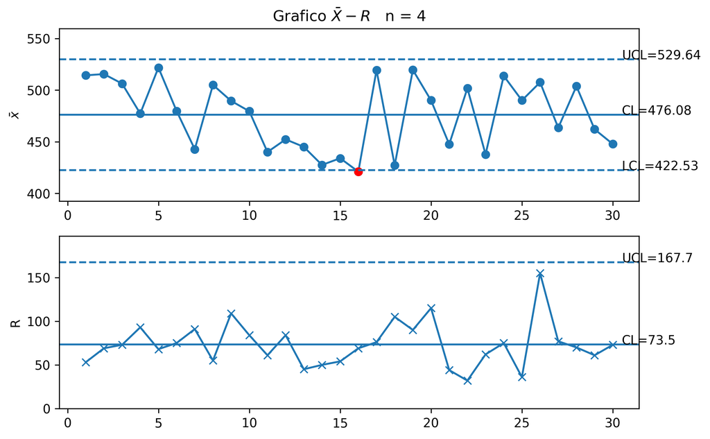

```python
from IPython.display import display
from PIL import Image

img = Image.open('../QCKentei3/Graph3/Kanrizu_2_5_1.png')
display(img)
```

## 5.1

群の大きさ $ n = 6 $ の $ \bar{X} - R $ 管理図において、 $ \bar{X} $ 管理図の管理限界および $ R $ 管理図の管理限界を求めよ。ただし $ \bar{ \bar{X}} = 42.15 $、$ \bar{R} = 2.03 $ とする。

En un gráfico de control $ \bar{X} - R $ con tamaño de grupo $ n = 6 $, determine los límites de control del gráfico \ bar{X} $ y los límites de control del gráfico $ R $, dado que \bar{ \bar{X}} = 42.15 $ y $ \bar{R} = 2.03 $

```python
from logging import error

def get_cell_value(df, row_index, col_name):
    try:
        return df.loc[row_index, col_name]
    except KeyError as e:
        return f"No hay valor de: {e}"
```

```python
n = 6
xbar = 42.15
R = 2.03

# Línea de control del gráfico Xbar
UCL_X = xbar + get_cell_value(df, n, 'A2') * R
LCL_X = xbar - get_cell_value(df, n, 'A2') * R
print(f"Límites de control del gráfico Xbar:\n UCL = {UCL_X:.2f}, LCL = {LCL_X:.2f}")

# Línea de control del gráfico R
UCL_R = get_cell_value(df, n, 'D4') * R
LCL_R = get_cell_value(df, n, 'D3') * R
print(f"\nLímites de control del gráfico R:\n UCL = {UCL_R:.1f}, LCL = {LCL_R}")
```

```
Límites de control del gráfico Xbar:
 UCL = 43.13, LCL = 41.17

Límites de control del gráfico R:
 UCL = 4.1, LCL = nan
```

#### (2) Gráfico de control $ \bar{X} - s $

El gráfico de control $ \bar{X} - s $ es un gráfico que utiliza la desviación estándar $ s $, calculada a partir de los datos de cada grupo, en lugar del rango $ R $ que se emplea en el gráfico de control $ \bar{X} - R $. Cuando el tamaño del grupo es grande, la precisión del rango R disminuye, por lo que es preferible utilizar la desviación estándar $ s $.

Paso 1: Recolectar los datos y agruparlos データを収集し、群分けする

Paso 2: Calcular la media y la desviación estándar de cada grupo 群ごとの平均値と標準偏差を計算する

Paso 3: Calcular la media general de todas las medias y la media de las desviaciones estándar 全てのデータの総平均値と標準偏差の平均値を計算する

Paso 4: Calcular las líneas de control 管理線を計算する

- Línea de control del gráfico $ \bar{X} $
  - Linea central: $ CL = \bar{X}$
  - Límite superior: $ UCL = \bar{X} + A_3 \bar{s} $
  - Límite inferior: $ LCL = \bar{X} - A_3 \bar{s} $
- Línea de control del gráfico $ R $
  - Linea central: $ CL = \bar{s}$
  - Límite superior: $ UCL = B_4 \bar{s} $
  - Límite inferior: $ LCL = B_3 \bar{s} $

Paso 5: Elaborar el gráfico de control 管理図を作成する

[Audio_5](https://drive.google.com/file/d/1IdSY6n-xxpVO62WIP05HC8Bl4vMR7x1i/view?usp=drive_link)

```python
sheet = client.open_by_key(SPREADSHEET_ID).worksheet("Sheet12") # 最初のシートを取得

# データを取得
list_of_lists = sheet.get_all_records()
df2 = pd.DataFrame(list_of_lists)

df2.set_index('n', inplace=True)

df2 = df2.apply(pd.to_numeric, errors='coerce')
df2.index = df2.index.astype(int)

print("Tabla 5.3")
print(df2)
```

```
Tabla 5.3
       A3     B3     B4
n
2   2.659    NaN  3.267
3   1.954    NaN  2.568
4   1.628    NaN  2.266
5   1.427    NaN  2.089
6   1.287  0.030  1.970
7   1.182  0.118  1.882
8   1.099  0.185  1.815
9   1.032  0.239  1.761
10  0.975  0.284  1.716
11  0.927  0.321  1.679
12  0.886  0.354  1.646
13  0.850  0.382  1.618
14  0.817  0.406  1.594
15  0.789  0.428  1.572
16  0.763  0.448  1.552
17  0.739  0.466  1.534
18  0.718  0.482  1.518
19  0.698  0.497  1.503
20  0.680  0.510  1.490
```

## 5.2

群の大きさ $ n=15 $ の $ \bar{X} - s $ において、 $ \bar{X} $ 管理図の管理限界および $ s $ 管理図の管理限界を求めよ、ただし、$ \bar{X} = 21.31 $、$ \bar{s} = 2.324 $ とする。

En un gráfico de control $ \bar{X} - s $ con tamaño de grupo $ n=15 $, determine los límites de control del gráfico $ \bar{X} $ y los límites de control del gráfico $ s $, dado que $ \bar{X} = 21.31 $ y $ \bar{s} = 2.324 $.

```python
n = 15
xbar = 21.31
s = 2.324

# Línea de control del gráfico Xbar
UCL_X = xbar + get_cell_value(df2, n, 'A3') * s
LCL_X = xbar - get_cell_value(df2, n, 'A3') * s
print(f"Límites de control del gráfico Xbar:\n UCL = {UCL_X:.2f}, LCL = {LCL_X:.2f}")

# Línea de control del gráfico R
UCL_s = get_cell_value(df2, n, 'B4') * s
LCL_s = get_cell_value(df2, n, 'B3') * s
print(f"\nLímites de control del gráfico s:\n UCL = {UCL_s:.3f}, LCL = {LCL_s:.3f}")
```

```
Límites de control del gráfico Xbar:
 UCL = 23.14, LCL = 19.48

Límites de control del gráfico s:
 UCL = 3.653, LCL = 0.995
```

#### (3) Cómo elaborar un gráfico de control $ X $ (gráfico $ X - R_m $)

El gráfico de control X es un gráfico que, a diferencia del gráfico $ \bar{X} - R $, no agrupa los datos（群分けをせず）, sino que traza cada punto individualmente. Se utiliza cuando solo se puede obtener un dato por lote o cuando el intervalo entre las mediciones es largo, registrando los datos uno por uno tal como se obtienen.

Existen dos métodos para elaborar un gráfico $ X $. Uno que determina las líneas de control a partir del rango móvil（移動範囲） (gráfico $ X - R_m $), y otro que agrupa（群分け） los datos para determinar las líneas de control (gráfico $ X - \bar{X} - R $).

Paso 1: Recolectar los datos y agruparlos データを収集する

Paso 2: Calcular el rango móvil $ R_m $ 移動範囲を求める

Paso 3: Calcular la media $ \bar{X} $ y la media de los rangos móviles $ \bar{R_m} $ 平均値と移動範囲の平均値を計算する

Paso 4: Calcular las línea de control 管理線を計算する

- Línea de control del gráfico $ \bar{X} $
  - Linea central: $ CL = \bar{X}$
  - Límite superior: $ UCL = \bar{X} + E_2 \bar{R_m} $
  - Límite inferior: $ LCL = \bar{X} - E_2 \bar{R_m} $
- Línea de control del gráfico $ R_m $
  - Linea central: $ CL = \bar{s}$
  - Límite superior: $ UCL = D_4 \bar{R_m} $
  - Límite inferior: $ LCL = D_3 \bar{R_m} $

Paso 5: Elaborar el gráfico de control 管理図を作成する

[Audio_6](https://drive.google.com/file/d/1UlhmB2k8OToFKTozloQFGW0YbJe3DPyP/view?usp=drive_link)

## 5.3

$ X - R_m $ 管理図において、X管理図の管理限界および Rm管理図の管理限界をもとめよ。ただし、$ \bar{X} = 41.5 $、$ \bar{R_m} = 2.3 $ とする。

En un gráfico de control $ X - R_m $ determine los límites de control del gráfico X y los límites de control del gráfico Rm, dado que $ \bar{X} = 41.5 $ y $ \bar{R_m} = 2.3 $

```python
n = 2
xbar = 41.5
Rm = 2.3

# Línea de control del gráfico Xbar
UCL_X = xbar + get_cell_value(df, n, 'E2') * Rm
LCL_X = xbar - get_cell_value(df, n, 'E2') * Rm
print(f"Límites de control del gráfico Xbar:\n UCL = {UCL_X:.1f}, LCL = {LCL_X:.1f}")

# Línea de control del gráfico Rm
UCL_R = get_cell_value(df, n, 'D4') * Rm
LCL_R = get_cell_value(df, n, 'D3') * Rm
print(f"\nLímites de control del gráfico Rm:\n UCL = {UCL_R:.1f}, LCL = {LCL_R}")
```

```
Límites de control del gráfico Xbar:
 UCL = 47.6, LCL = 35.4

Límites de control del gráfico Rm:
 UCL = 7.5, LCL = nan
```

### 2. Cómo elaborar un gráfico de control para datos por atributos

計量値の管理図のつくり方

#### (1) Cómo elaborar un gráfico de control $ p $

- Cuando el tamaño de los grupos varía, se representan en el gráfico de control las proporciones de unidades no conformes de cada grupo. Se utiliza cuando se desea gestionar y analizar la variación de la proporción de unidades no conformes entre los grupos. （群の大きさが群ごとに異なる場合）

Paso 1: Recopilar los datos データを収集する

Paso 2: Calcular la proporción de unidades no conformes $ p $ para cada grupo 群ごとの不適合品率を計算する

Paso 3: Calcular la proporción promedio de unidades no conformes $ \bar{p} $ 平均不適合品率を計算する

Paso 4: Calcular las línea de control 管理線を計算する

- Línea de control del gráfico $ p $
  - Linea central: $ CL = \bar{p}$
  - Límite superior: $ UCL = \bar{p} + 3 \sqrt{\frac{1}{n_i}\bar{p}(1-\bar{p})} $
  - Límite inferior: $ LCL = \bar{p} - 3 \sqrt{\frac{1}{n_i}\bar{p}(1-\bar{p})} $

Paso 5: Elaborar el gráfico de control 管理図を作成する

[Aidop_7](https://drive.google.com/file/d/1STMx2WXn5Okyvk1nyCVqGCBiCbk3amvy/view?usp=drive_link)

## 5.4

群の大きさｎが１００～２００で群ごとに異なっているｐ管理図について群の大きさが n=180 である群の管理限界を求めよ。ただし、$ \bar{p} = 0.045 $ とする。

En un gráfico de control $ p $ donde el tamaño del grupo n varía entre 100 y 200, calcule los límites de control para un grupo cuyo tamaño es n=180. Se de que $ \bar{p} = 0.045 $

```python
n = 180
pbar = 0.045

# Línea de control del gráfico Xbar
UCL_p = pbar + 3 * np.sqrt((1/n) * pbar*(1-pbar))
LCL_p = max(pbar - 3 * np.sqrt((1/n) * pbar*(1-pbar)),0)
print(f"Límites de control del gráfico p:\n UCL = {UCL_p:.3f}, LCL = {LCL_p:.3f}")
```

```
Límites de control del gráfico p:
 UCL = 0.091, LCL = 0.000
```

#### (2) Cómo elaborar un gráfico de control $ np $

（各群の大きさが一定の場合のみに用いる）

Paso 1: Recopilar los datos データを収集し、群分けする

Paso 2: Calcular la proporción de unidades no conformes $ p $ para cada grupo 平均不適合品率を計算する

Paso 3: Calcular la proporción promedio de unidades no conformes $ \bar{p} $ 管理線を計算する

Paso 4: Calcular las línea de control 管理図を作成する

- Línea de control del gráfico $ np $
  - Linea central: $ CL = n\bar{p}$
  - Límite superior: $ UCL = n\bar{p} + 3 \sqrt{n\bar{p}(1-\bar{p})} $
  - Límite inferior: $ LCL = n\bar{p} - 3 \sqrt{n\bar{p}(1-\bar{p})} $

Paso 5: Elaborar el gráfico de control 管理図を作成する

[Audio_8](https://drive.google.com/file/d/14vVDim_0KUgSHQBr3HUOtvUOs6azaRpZ/view?usp=drive_link)

## 5.5

群の大きさ n=180 で一定である np管理図について管理限界を求めよ。ただし、$ \bar{p} = 0.045 $ とする。

En un gráfico de control np con tamaño de grupo constante n=180, calcule los límites de control. Se da que $ \bar{p} = 0.045 $

```python
n = 180
pbar = 0.045

# Línea de control del gráfico Xbar
UCL_p = n * pbar + 3 * np.sqrt(n * pbar*(1-pbar))
LCL_p = max(n * pbar - 3 * np.sqrt(n * pbar*(1-pbar)),0)
print(f"Límites de control del gráfico np:\n UCL = {UCL_p:.1f}, LCL = {LCL_p:.3f}")
```

```
Límites de control del gráfico np:
 UCL = 16.4, LCL = 0.000
```

#### (3) Cómo elaborar un gráfico de control $ u $

En gráfico de control para el número de no conformidades, como número de defectos en un producto o el número de accidentes. Cuando el tamaño del grupo n, es decir, el tamaño de la muestra inspeccionada, varía entre los grupos, se representa y controla en el gráfico el número de no conformidades por unidad para cada grupo. （調査するサンプルの大きさである群の大きさが群ごとに異なる場合）

Paso 1: Recopilar los datos y agruparlos. データを収集し、群分けを行う

Paso 2: Calcular el número de no conformidades por unidad $ u $ para cada grupo. 群ごとの単位当たりの不適合数を計算する

Paso 3: Calcular el número promedio de no conformidades por unidad $ \bar{u} $ 平均不適合数を計算する

Paso 4: Calcular las líneas de control. 管理線を計算する

- Línea de control del gráfico $ n $
  - Linea central: $ CL = \bar{u}$
  - Límite superior: $ UCL = \bar{u} + 3 \sqrt{\frac{u}{n_i}} $
  - Límite inferior: $ LCL = \bar{u} - 3 \sqrt{\frac{u}{n_i}} $

Paso 5: Elaborar el gráfico de control 管理図を作成する

[Audio_9](https://drive.google.com/file/d/16XKizJkwGCzlUVR-FylqPVUlmH9hFyue/view?usp=drive_link)

## 5.6

群の大きさ n が１０～２０で群ごとに異なっている u 管理図について、群の大きさ n=15 である群の管理限界を求めよ。ただし、 $ \bar{u} = 0.300 $ とする。

Para un gráfico de control $ u $ en el que el tamaño del grupo n varía entre 10 y 20, calcule los límites de control para un grupo cuyo tamaño es n=15. Se supone que $ \bar{u} = 0.300 $

```python
n = 15
ubar = 0.300

# Línea de control del gráfico Xbar
UCL_u = ubar + 3 * np.sqrt(ubar/n)
LCL_u = max(ubar - 3 * np.sqrt(ubar/n),0)
print(f"Límites de control del gráfico u:\n UCL = {UCL_u:.3f}, LCL = {LCL_u:.3f}")
```

```
Límites de control del gráfico u:
 UCL = 0.724, LCL = 0.000
```

#### (4) Cómo elaborar un gráfico de control $ c $

En un gráfico de control del número de no conformidades, como el número de defectos en un producto o la cantidad de accidentes. Se utiliza cuando el tamaño del grupo, es decir, el tamaño de la muestra investigada, es constante. Se representa y controla en el gráfico de control los números de no conformidades por grupo. （調査するサンプルの大きさである群の大きさが一定の場合に用いる）

Paso 1: Recopilar los datos y agruparlos. データを収集し、群分けをする

Paso 2: Calcular el número promedio de no conformidades $ \bar{c} $ 平均不適合数を計算する

Paso 3: Calcular las líneas de control. 管理線を計算する

- Línea de control del gráfico $ c $
  - Linea central: $ CL = \bar{c}$
  - Límite superior: $ UCL = \bar{c} + 3 \sqrt{\bar{c}} $
  - Límite inferior: $ LCL = \bar{c} - 3 \sqrt{\bar{c}} $

Paso 4: Elaborar el gráfico de control 管理図を作成する

[Audio_11](https://drive.google.com/file/d/1tFP2hEKn3sfnCbrlt2koLSHJ9XQytShE/view?usp=drive_link)

## 5.7

群の大きさが一定であるｃ管理図について管理限界を求めよ。ただし、$ \bar{c} = 3.0 $ とする。

Para el gráfico de control c, donde el tamaño del grupo es constante, calcule los límites de control. Suponga que $ \bar{c} = 3.0 $

```python
cbar = 3.00

# Línea de control del gráfico c
UCL_c = cbar + 3 * np.sqrt(cbar)
LCL_c = max(cbar - 3 * np.sqrt(cbar),0)
print(f"Límites de control del gráfico c:\n UCL = {UCL_c:.1f}, LCL = {LCL_c:.1f}")
```

```
Límites de control del gráfico c:
 UCL = 8.2, LCL = 0.0
```

## 5.8

以下に示す各工程において、管理図を用いた調査や工程管理を実施したい。適切な管理図の名称を答えよ。

Se desea realizar investigaciones y control de procesos mediante diagramas de control en cada una de las etapas que se indican a continuación. Indique el nombre del diagrama de control apropiado.

1. Se desea analizar la variación en las dimensiones (mm) de la parte de peso de la porción especial. Dado que el número de unidades producidas por día es alto, se toman 12 muestras diarias y se miden sus dimensiones para obtener los datos.

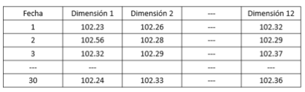

```python
img = Image.open('./Data2/3-8-1.png')
display(img)
```

1. Se desea analizar la variación del peso (g) de las piezas de resina. Se toman 4 muestras por día, se mide su peso y registran los datos.

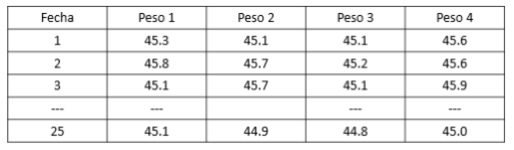

```python
img = Image.open('./Data2/3-8-2.png')
display(img)
```

1. Se desea analizar y controlar la variación de la dureza superficial (HV) de componentes de gran tamaño. Se produce un producto por día y se mide su dureza para obtener los datos.

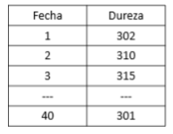

```python
img = Image.open('./Data2/3-8-3.png')
display(img)
```

1. Se fabrican envases de plástico y se desea investigar y controlar los defectos de apariencia. Cada día se toman 400 muestras y se cuenta el número de productos no conformes en la muestra para registrar los datos.

[figure not shown]

```python
img = Image.open('./Data2/3-8-4.png')
display(img)
```

1. Se fabrican tableros decorativos. Se han detectado marcas de golpes en la superficie y se desea investigarlas. Cada día se toman 2 productos de 8 metros cuadrados y se cuenta el número de marcas de golpes (no conformidades) para registrar los datos.

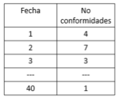

```python
img = Image.open('./Data2/3-8-5.png')
display(img)
```

1. Se fabrican botellas de vidrio. Se han detectado burbujas y se desea investigarlas. Como la cantidad de producción diaria varía, el número de unidades inspeccionadas también varía según el día. Se cuenta el número de productos no conformes con burbujas en la muestra para registrar los datos.

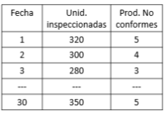

```python
img = Image.open('./Data2/3-8-6.png')
display(img)
```

1. Se fabrican láminas metálicas. Se han detectado rayaduras y se desea investigarlas. Como el tamaño de las láminas producidas varía cada día, también varía el área inspeccionada (en metros cuadrados). Se cuenta el número de rayaduras (no conformidades) en la muestra para registrar los datos.

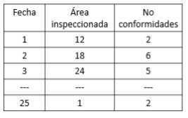

```python
img = Image.open('./Data2/3-8-7.png')
display(img)
```

1. Gráfico de control $ \bar{X} - s $
2. Gráfico de control $ \bar{X} - R $
3. Gráfico de control $ \bar{X} - Rm $
4. Gráfico de control $ np $
5. Gráfico de control $ c $
6. Gráfico de control $ p $
7. Gráfico de control $ u $

## 05-03 Interpretación del gráfico de control

管理図の見方

### 1. Interpretación del gráfico de control

管理図の見方

En la gestión de procesos, es crucial determinar correctamente si un proceso está en estado de control estadístico mediante gráficos de control. Si se detecta una anomalía, es necesario investigar su causa de inmediato y tomar las medidas correctivas pertinentes.

#### (1) Determinación del estado de control estadístico

統計的管理状態の判定

El estado de control estadístico se refiere a la situación en la que un proceso está influenciado únicamente por causas aleatorias.

1. Si los puntos del gráfico de control están dentro de los límites de control.
2. y no hay patrones inusuales en la secuencia de los puntos,

entonces el proceso se considera en estado de control.

En un gráfico de control $ \bar{X} $, si cada subgrupo sigue la misma distribución $ N (\mu_0, \sigma_0^2) $ se considera que el proceso está en un estado estable.

En los gráficos de control del método de las 3 sigmas, el error de juzgar que hay una anomalía cuando no la hay en el proceso se mantiene muy bajo, en un 0.3%. Por lo tanto, si un punto cae fuera de los límites de control, es casi seguro que se puede concluir que hay una anomalía. Por otro lado, también existe el error de juzgar que no hay ninguna anomalía cuando si la hay en el proceso. Para reducir este error, se realizan juicios adicionales basados en patrones de puntos y la tendencia de su dispersión.

#### (2) Reglas para la detección de anomalías en el proceso

工程異常の判定のためのルール

[Audio_10](https://drive.google.com/file/d/1Kkpb7fI9fE6dPjJfvPT1fnz7km1ml-n-/view?usp=drive_link)

1. Un punto del gráfico de control está fuera de los límites de control (Regla 1)

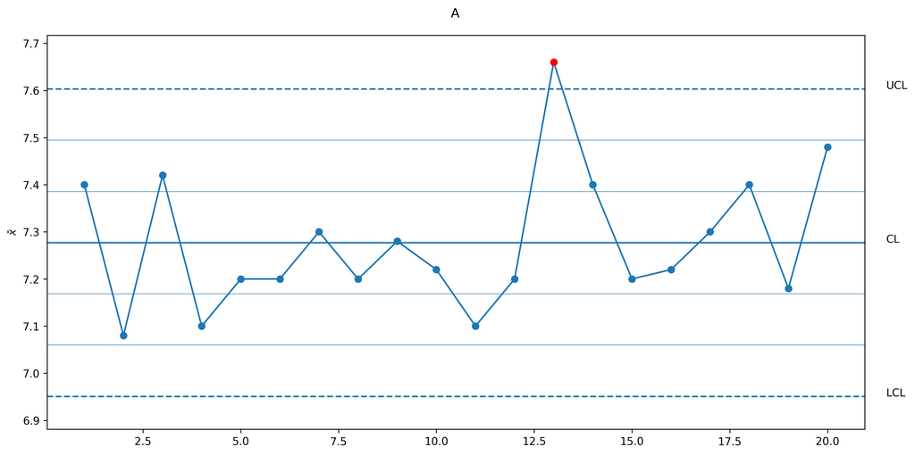

```python
from IPython.display import display
from PIL import Image

img = Image.open('../QCKentei3/Graph3/Kanrizu_2_A.png')
display(img)
```

1. Cuando los puntos aparecen consecutivamente en el mismo lado de la líneas central (Regra 2) 点が中心に対して同じ側に連続して現れる

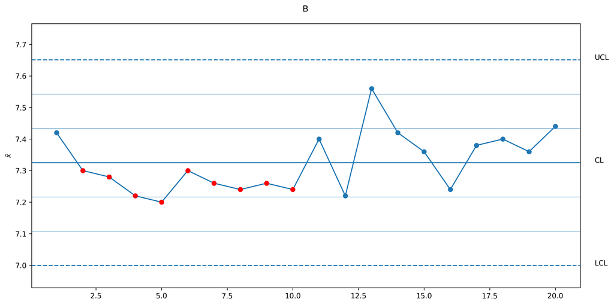

```python
img = Image.open('../QCKentei3/Graph3/Kanrizu_2_B.png')
display(img)
```

1. Puntos que continúan aumentando o disminuyendo (Regla 3) 点が引き続き増加または減少している

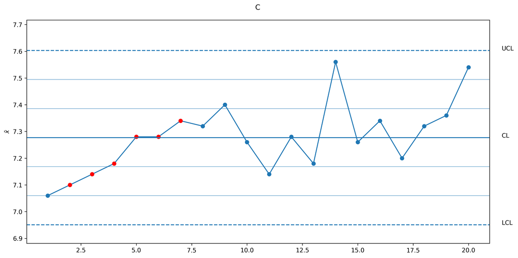

```python
img = Image.open('../QCKentei3/Graph3/Kanrizu_2_C.png')
display(img)
```

1. Puntos con un patrón claramente no aleatorio o un patrón periódico (Regla 4) 点が明らかに不規則でないパターン又は周期的なパターン

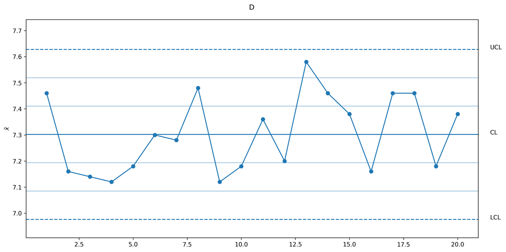

```python
img = Image.open('../QCKentei3/Graph3/Kanrizu_2_D.png')
display(img)
```

## Por favor, responda a las preguntas del examen de práctica a través del siguiente enlace.

[Simulacro de examen](https://forms.gle/PVpJuexXHX9dgNmE9)

```python
notebook_name = 'QCKentei2-5.ipynb'
notebook_name_html = notebook_name.replace(".ipynb",".html")

!jupyter nbconvert --to html {notebook_name}
```

```
[NbConvertApp] Converting notebook QCKentei2-5.ipynb to html
[NbConvertApp] Writing 3249779 bytes to QCKentei2-5.html
```

```python
import re

def get_file_id(url,out):
    # 正規表現でファイルIDを抽出
    match = re.search(r'/d/([a-zA-Z0-9_-]+)', url)

    if match:
        file_id = match.group(1)
        print("ファイルID:", file_id)
    else:
        print("ファイルIDが見つかりませんでした。")

    url = f"https://drive.google.com/uc?id={file_id}"

    output = out

    gdown.download(url, output, quiet=False)

    img = Image.open(out)
    display(img)
```

```python
#!pip install -q gdown

#https://drive.google.com/file/d/12nlkHSsF0S1b87gtt9kHUl_a8nwJGf1V/view?usp=drive_link

from IPython.display import display
from PIL import Image
import gdown

file_id = "12nlkHSsF0S1b87gtt9kHUl_a8nwJGf1V"
url = f"https://drive.google.com/uc?id={file_id}"

output = "./Data2/3-8-1.png"

#gdown.download(url, output, quiet=False)

#img = Image.open('./Data2/3-8-1.png')
#display(img)
```

```python
#https://drive.google.com/file/d/11mFMkQWKZe9Rdun8scQPi-zTFwRBf-8C/view?usp=drive_link

file_id = "11mFMkQWKZe9Rdun8scQPi-zTFwRBf-8C"
url = f"https://drive.google.com/uc?id={file_id}"

output = "./Data2/3-8-2.png"

#gdown.download(url, output, quiet=False)

#img = Image.open('./Data2/3-8-2.png')
#display(img)
```

```python
#https://drive.google.com/file/d/1Zcpxc_diee5KSNN5hp0hsj6U2baeVR35/view?usp=drive_link

file_id = "1Zcpxc_diee5KSNN5hp0hsj6U2baeVR35"
url = f"https://drive.google.com/uc?id={file_id}"

output = "./Data2/3-8-3.png"

#gdown.download(url, output, quiet=False)

#img = Image.open('./Data2/3-8-3.png')
#display(img)
```

```python
#https://drive.google.com/file/d/1vXaW0OMm60h6Z5Lnz9fg0vUwE-AaM_6r/view?usp=drive_link

file_id = "1Zcpxc_diee5KSNN5hp0hsj6U2baeVR35"
url = f"https://drive.google.com/uc?id={file_id}"

output = "./Data2/3-8-4.png"

#gdown.download(url, output, quiet=False)

#img = Image.open('./Data2/3-8-4.png')
#display(img)
```

```python
# 対象のURL
url = 'https://drive.google.com/file/d/1peYnoT90d0fjS7FXlzujzJbqi2i5hQLW/view?usp=drive_link'
out = "./Data2/3-8-5.png"

#get_file_id(url,out)
```

```python
url= 'https://drive.google.com/file/d/19piEoCr6zTHvG_FFs7mZHhHwNumerEwT/view?usp=drive_link'
out = './Data2/3-8-6.png'
#get_file_id(url,out)
```

```python
url= 'https://drive.google.com/file/d/1DKULLfmRphDATYhGKaRrwE5ox0oXnAxy/view?usp=drive_link'
out = './Data2/3-8-7.png'
#get_file_id(url,out)
```